# BacLe Project4 Bank Churn Prediction Updated 082024

#### Roc Curve Display

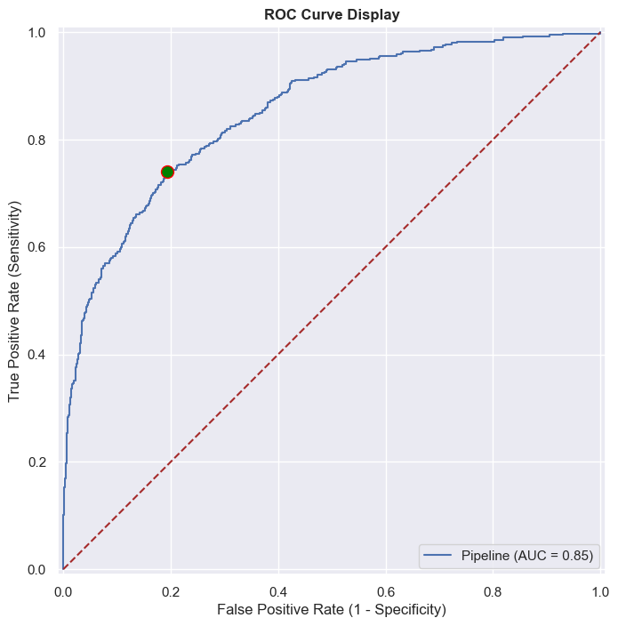

```python
# Plot using RocCurveDisplay

RocCurveDisplay.from_estimator(final_pipeline, X_test, y_test);
plt.rcParams['figure.figsize'] = [5, 5]
plt.plot([0,1], [0,1], color='brown', linestyle='--')
plt.xlabel('False Positive Rate (1 - Specificity)', fontsize=12)
plt.ylabel('True Positive Rate (Sensitivity)', fontsize=12)
plt.title('ROC Curve Display', fontweight='bold', fontsize=12)
plt.plot(fpr[optimal_thresthold_index], tpr[optimal_thresthold_index], \
         marker='o', markersize=10, markeredgecolor='red', markerfacecolor='green')
plt.show();
```

##### Observations (Roc Curve Display):

- The green dot with a red edge represents the optimal threshold at 0.741.

#### Feature Importance with Shap

```python
X_train_shap = (preprocessor.fit_transform(X_train)).sample(n = 1000)
```

```python
X_test_shap = (preprocessor.fit_transform(X_test)).sample(n=200)
```

```python
explainer = shap.Explainer(final_model.predict, X_train_shap)
```

```python
shap_values = explainer(X_test_shap)
```

```
PermutationExplainer explainer: 201it [07:40,  2.34s/it]
```

```python
shap.initjs()
```

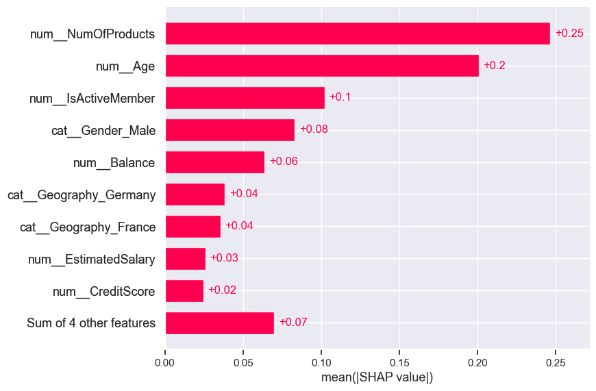

```python
shap.plots.bar(shap_values)
```

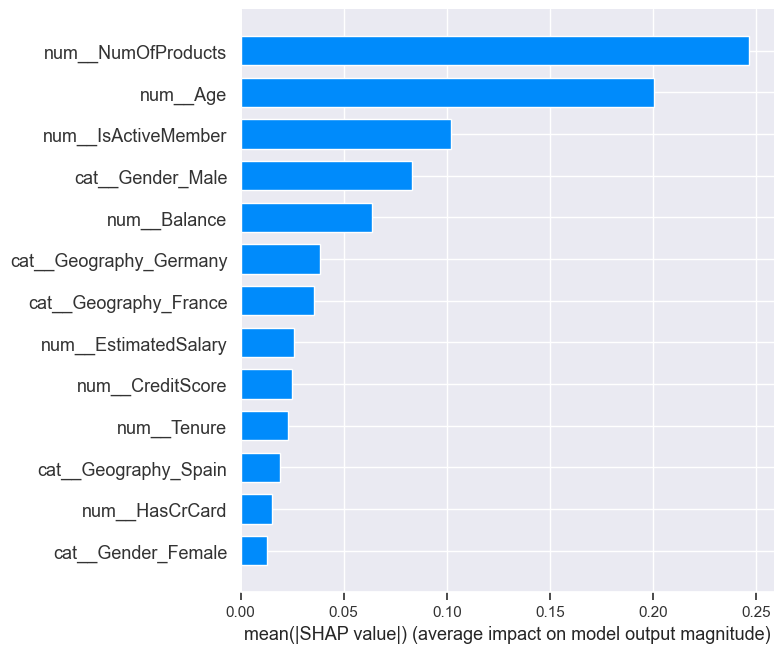

```python
shap.summary_plot(shap_values.values, X_train_shap, plot_type='bar')
```

##### Observations (Feature Importance):

- NumOfProducts, Age, IsActiveMember, Balance, and Male are the top 5 important features.

#### Ann Model Churn Prediction Testing Phase

```python
# Select 5 random samples
test_data = df1.sample(n=5, random_state=100)
```

```python
test_data
```

|  | CreditScore | Geography | Gender | Age | Tenure | Balance | NumOfProducts | HasCrCard | IsActiveMember | EstimatedSalary | Exited |
| --- | --- | --- | --- | --- | --- | --- | --- | --- | --- | --- | --- |
| 8018 | 632 | Germany | Male | 23 | 3 | 122478.510 | 1 | 1 | 0 | 147230.770 | 1 |
| 9225 | 594 | Germany | Female | 32 | 4 | 120074.970 | 2 | 1 | 1 | 162961.790 | 0 |
| 3854 | 687 | Germany | Male | 33 | 9 | 135962.400 | 2 | 1 | 0 | 121747.960 | 0 |
| 2029 | 520 | France | Male | 33 | 4 | 156297.580 | 2 | 1 | 1 | 166102.610 | 0 |
| 3539 | 667 | France | Male | 42 | 6 | 0.000 | 1 | 1 | 0 | 88890.050 | 0 |

```python
# Split data
X_data = test_data.drop(['Exited'], axis=1)
y_data = test_data['Exited']
```

```python
# Make predictions
y_data_probs = final_pipeline.predict_proba(X_data)[:,1]
y_data_probs
```

```
array([0.55453926, 0.42532015, 0.36336696, 0.20867196, 0.8891876 ],
      dtype=float32)
```

```python
y_data_pred = (y_data_probs > 0.5)
y_data_pred
```

```
array([ True, False, False, False,  True])
```

```python
# Validate predictions
print(classification_report(y_data, y_data_pred, digits=2))
```

```
              precision    recall  f1-score   support

           0       1.00      0.75      0.86         4
           1       0.50      1.00      0.67         1

    accuracy                           0.80         5
   macro avg       0.75      0.88      0.76         5
weighted avg       0.90      0.80      0.82         5
```

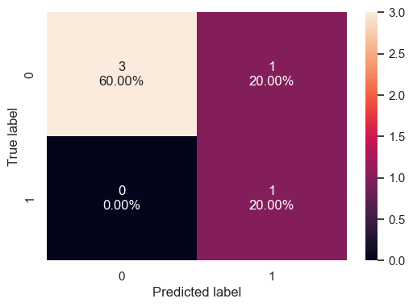

```python
confusion_matrix_sklearn(final_pipeline, X_data, y_data)
```

##### Observations (Prediction):

- With 5 samples of input data, the model can accurately predict one churner (TP) and three non-churners (TN).
- However, the model fails to predict one non-churner to churn (FP).
- The predictions may vary with different test data, but at least in this case the model can achieve 100% Recall, no FN.

### Summary:

- All required libraries are imported in addition to TensorFlow.keras and SciKeras wrapper to bridge with Scikit_learn
- StandardScaler and OneHotEncoder are used as preprocessors in this project.
- Instantiate and train 5 models with default parameters on the training dataset. Check Recall and Loss scores on the training and validation set.
- Oversampling training data with SMOTE (Synthetic Minority Over Sampling Technique) and using the dropout method for model improvement.
- Hypertuning a preferred model with GridSearch, RandomSearch with SMOTE, BayesSearch, and Keras Tuner to find the best estimator and parameters.
- Evaluate the final model with Confusion Matrix, StratifiedKFold Cross Validation, and determine the optimal threshold for ROC curve display.
- Feature Importance with Shap is generated to give us some insights into the black box model.
- In conclusion, RandomSearch with SMOTE turns out to produce the best model for this project with the highest Recall score of 89%. However, a deeper third layer with more neurons and a small dropout rate helps improve the convergence of the final model.

## Actionable Insights and Business Recommendations

[output not shown]

Power Ahead ___